# RBP workflow

```r
library(SummarizedExperiment)
library(GenomicFeatures)
library(dplyr)
library(ggplot2)
library(satuRn)
library(limma)
library(tibble)
library(here)
# splicelogic devel, loaded from source: clone the repo next to this one
#   git clone -b devel https://github.com/thelovelab/splicelogic.git ../splicelogic
# then load it with devtools (install.packages("devtools") if needed)
devtools::load_all(here("../splicelogic"))
```

```r
# dir <- system.file("extdata", package = "splicelogic")
# se <- readRDS(file.path(dir, "GTEx_v9_ONT_SummarizedExperiment.rds"))
se <- readRDS(here("workflows/data/GTEx_v9_ONT_SummarizedExperiment.rds"))
dim(se)
```

```
## [1] 385669     11
```

```r
keep <- rowSums(assay(se) >= 10) >= 6
se <- se[keep, ]
dim(se)
```

```
## [1] 18985    11
```

```r
# filters: 385669 -> 18985 transcripts

library(DESeq2)
library(tximeta)
colsums <- colSums(assay(se, "counts"))
cpm <- t(t(assay(se, "counts")) / colsums * 1e6)
assay(se, "abundance") <- cpm

# dummy lengths... no correction for length
assay(se, "length", withDimnames=FALSE) <- matrix(1000, nrow=nrow(se), ncol=ncol(se))
```

How many samples each donor contributes to each condition, before `ctrl` / `exp` are relabelled WT / KD below.

```r
samples_per_donor <- as.data.frame(colData(se)) |>
  dplyr::count(donor, condition) |>
  tidyr::pivot_wider(names_from = condition, values_from = n, values_fill = 0) |>
  dplyr::mutate(total = ctrl + exp)

# with a total row
dplyr::bind_rows(
  samples_per_donor,
  dplyr::summarise(samples_per_donor, donor = "total",
                   dplyr::across(c(ctrl, exp, total), sum))
)
```

```
## # A tibble: 5 × 4
##   donor  ctrl   exp total
##   <chr> <int> <int> <int>
## 1 QEG5      1     1     2
## 2 QV44      2     1     3
## 3 S4Z8      1     2     3
## 4 S95S      1     2     3
## 5 total     5     6    11
```

How the object was built, from `metadata(se)`. tximeta records its own version, the quantifier and the transcriptome. `quantInfo` holds oarfish’s `meta_info.json` settings, which in this run do not include the oarfish version (unlike salmon’s `salmon_version`), so that has to come from the original run.

```r
md <- metadata(se)
tibble::tibble(
  field = c("tximeta version", "quantifier", "transcriptome", "genome",
            "import time"),
  value = c(as.character(md$tximetaInfo$version), md$tximetaInfo$type,
            md$txomeInfo$index, md$txomeInfo$genome,
            format(md$tximetaInfo$importTime))
)
```

```
## # A tibble: 5 × 2
##   field           value
##   <chr>           <chr>
## 1 tximeta version 1.30.0
## 2 quantifier      oarfish
## 3 transcriptome   gencode.v48
## 4 genome          GRCh38
## 5 import time     2026-05-08 11:11:52
```

```r
# oarfish settings, identical across the 11 samples
unique(md$quantInfo$prob_model)
```

```
## [1] "no_coverage"
```

```r
unique(md$quantInfo$alignment_source)
```

```
## [1] "from_raw_reads"
```

## DTU testing with satuRn

We compare the experiment condition (`exp`, RBP knockdown) against control (`ctrl`) using satuRn.

```r
colData(se)$condition <- dplyr::case_when(
    colData(se)$condition == "ctrl" ~ "WT",
    colData(se)$condition == "exp" ~ "KD"
)
# KD as reference level
colData(se)$condition <- factor(colData(se)$condition, levels = c("KD", "WT"))

# build design from the factor directly (matches satuRn vignette convention)
condition <- colData(se)$condition
donor <- factor(colData(se)$donor)
design <- model.matrix(~ 0 + condition + donor)

L <- limma::makeContrasts(
  WT_vs_KD = conditionWT - conditionKD,
  levels = design
)
L
```

```
##              Contrasts
## Levels        WT_vs_KD
##   conditionKD       -1
##   conditionWT        1
##   donorQV44          0
##   donorS4Z8          0
##   donorS95S          0
```

```r
rowData(se)$isoform_id <- rowData(se)$tx_name
# flatten CharacterList gene_id to plain character
rowData(se)$gene_id <- vapply(rowData(se)$gene_id, `[`, character(1), 1)

se <- se[
  duplicated(rowData(se)$gene_id) |
    duplicated(rowData(se)$gene_id, fromLast = TRUE),
]
# 18985 transcripts -> 11874 transcripts after removing single-isoform genes
se <- satuRn::fitDTU(se, formula = ~0 + condition + donor)
```

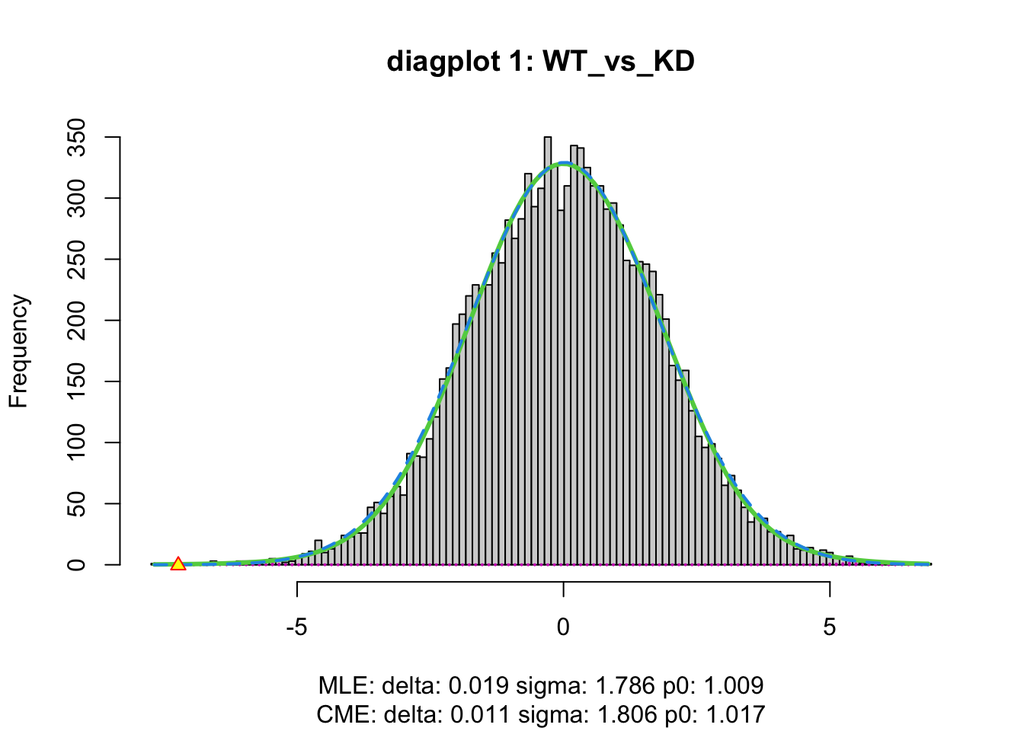

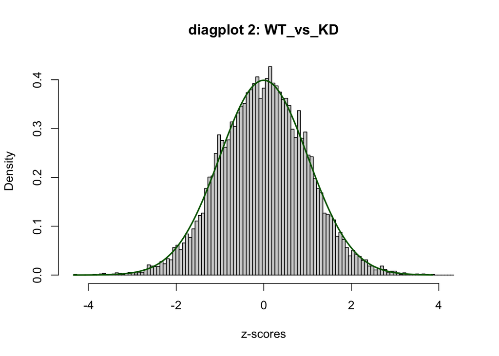

```r
se <- satuRn::testDTU(
  object = se,
  contrasts = L,
  diagplot1 = TRUE,
  diagplot2 = TRUE
)
```

```r
gene_ids <- rowData(se)$gene_id

# every tested transcript; `sig_res` below is the significant subset, and the
# non-significant rows are the background pool for slSampleNonEventExons()
dtu_res <- rowData(se)[["fitDTUResult_WT_vs_KD"]] |>
  as.data.frame() |>
  tibble::rownames_to_column("tx_name") |>
  tibble::as_tibble() |>
  dplyr::mutate(gene_id = gene_ids) |>
  dplyr::select(tx_name, gene_id, estimates, pval, regular_FDR) |>
  dplyr::arrange(pval)

sig_res <- dtu_res |> dplyr::filter(regular_FDR < 0.1)

sig_res <- sig_res |> mutate( tx_id = tx_name)
sig_res
```

```
## # A tibble: 1,987 × 6
##    tx_name            gene_id            estimates     pval regular_FDR tx_id
##    <chr>              <chr>                  <dbl>    <dbl>       <dbl> <chr>
##  1 ENST00000378292.9  ENSG00000198467.16      2.98 1.00e-14    1.19e-10 ENST000…
##  2 ENST00000355572.6  ENSG00000196923.14     -3.01 5.09e-12    3.02e- 8 ENST000…
##  3 ENST00000355841.7  ENSG00000196923.14      3.63 7.77e-12    3.08e- 8 ENST000…
##  4 ENST00000403994.9  ENSG00000140416.26     -3.92 1.66e-11    4.94e- 8 ENST000…
##  5 ENST00000311785.11 ENSG00000138674.17      1.84 2.18e-11    5.17e- 8 ENST000…
##  6 ENST00000358278.7  ENSG00000140416.26      2.82 3.85e-11    7.63e- 8 ENST000…
##  7 ENST00000292807.9  ENSG00000161203.14     -2.68 6.14e-11    8.47e- 8 ENST000…
##  8 ENST00000382456.7  ENSG00000161203.14      2.68 6.14e-11    8.47e- 8 ENST000…
##  9 ENST00000613865.5  ENSG00000138326.21      1.53 6.42e-11    8.47e- 8 ENST000…
## 10 ENST00000645482.3  ENSG00000198467.16     -3.50 7.22e-11    8.58e- 8 ENST000…
## # ℹ 1,977 more rows
```

How many transcripts and genes are left after the FDR < 0.1 cut, split by the sign of the estimate (> 0 = higher usage in WT, < 0 = higher usage in KD). A gene counts as up (or down) when at least one of its significant transcripts is; a gene with both is one where splicelogic has a pair to compare.

```r
sig_genes <- sig_res |>
  dplyr::group_by(gene_id) |>
  dplyr::summarise(n_up = sum(estimates > 0), n_down = sum(estimates < 0),
                   .groups = "drop")

tibble::tribble(
  ~level,        ~set,                                 ~n,
  "transcripts", "tested",                             nrow(dtu_res),
  "transcripts", "FDR < 0.1",                          nrow(sig_res),
  "transcripts", "FDR < 0.1, estimate > 0 (up, WT)",   sum(sig_res$estimates > 0),
  "transcripts", "FDR < 0.1, estimate < 0 (down, KD)", sum(sig_res$estimates < 0),
  "genes",       "tested",                             dplyr::n_distinct(dtu_res$gene_id),
  "genes",       "with >= 1 FDR < 0.1 transcript",     nrow(sig_genes),
  "genes",       "with >= 1 up transcript",            sum(sig_genes$n_up > 0),
  "genes",       "with >= 1 down transcript",          sum(sig_genes$n_down > 0),
  "genes",       "with >= 1 up and >= 1 down",         sum(sig_genes$n_up > 0 & sig_genes$n_down > 0)
) |>
  dplyr::mutate(pct = sprintf("%.1f%%", 100 * n / n[set == "tested"]),
                .by = level)
```

```
## # A tibble: 9 × 4
##   level       set                                    n pct
##   <chr>       <chr>                              <int> <chr>
## 1 transcripts tested                             11874 100.0%
## 2 transcripts FDR < 0.1                           1987 16.7%
## 3 transcripts FDR < 0.1, estimate > 0 (up, WT)     953 8.0%
## 4 transcripts FDR < 0.1, estimate < 0 (down, KD)  1034 8.7%
## 5 genes       tested                              4369 100.0%
## 6 genes       with >= 1 FDR < 0.1 transcript      1023 23.4%
## 7 genes       with >= 1 up transcript              849 19.4%
## 8 genes       with >= 1 down transcript            892 20.4%
## 9 genes       with >= 1 up and >= 1 down           718 16.4%
```

The same genes split into three groups by the direction of their significant transcripts, with how many transcripts each group holds. Only the “up and down” genes can give events; the other two are dropped by the filter below.

```r
gene_classes <- sig_genes |>
  dplyr::mutate(class = dplyr::case_when(
    n_up > 0 & n_down > 0 ~ "up and down",
    n_up > 0              ~ "up only",
    TRUE                  ~ "down only"
  )) |>
  dplyr::group_by(class = factor(class, levels = c("up only", "down only",
                                                   "up and down"))) |>
  dplyr::summarise(genes = dplyr::n(),
                   transcripts = sum(n_up + n_down),
                   up_tx = sum(n_up),
                   down_tx = sum(n_down)) |>
  dplyr::mutate(class = as.character(class))

# with a total row, which matches the FDR < 0.1 counts in the table above
dplyr::bind_rows(
  gene_classes,
  dplyr::summarise(gene_classes, class = "total",
                   dplyr::across(c(genes, transcripts, up_tx, down_tx), sum))
)
```

```
## # A tibble: 4 × 5
##   class       genes transcripts up_tx down_tx
##   <chr>       <int>       <int> <int>   <int>
## 1 up only       131         141   141       0
## 2 down only     174         181     0     181
## 3 up and down   718        1665   812     853
## 4 total        1023        1987   953    1034
```

```r
# the significant transcripts, filtered to those with a partner in the same gene:
# keep genes with >= 1 up and >= 1 down transcript (from `sig_genes` above).
# Events always pair an up with a down transcript of the same gene, so this
# only drops transcripts that could never be in an event; the events found
# below are identical with or without it.
paired_genes <- sig_genes$gene_id[sig_genes$n_up > 0 & sig_genes$n_down > 0]
sig_res <- sig_res |> dplyr::filter(gene_id %in% paired_genes)

c(transcripts = nrow(sig_res), genes = dplyr::n_distinct(sig_res$gene_id))
```

```
## transcripts       genes
##        1665         718
```

```r
# save sig_res for later use
saveRDS(sig_res, here("workflows/data/sig_res.rds"))
```

```r
# load the saved DTU results
sig_res <- readRDS(here("workflows/data/sig_res.rds"))
sig_res
```

```
## # A tibble: 1,665 × 6
##    tx_name            gene_id            estimates     pval regular_FDR tx_id
##    <chr>              <chr>                  <dbl>    <dbl>       <dbl> <chr>
##  1 ENST00000378292.9  ENSG00000198467.16      2.98 1.00e-14    1.19e-10 ENST000…
##  2 ENST00000355572.6  ENSG00000196923.14     -3.01 5.09e-12    3.02e- 8 ENST000…
##  3 ENST00000355841.7  ENSG00000196923.14      3.63 7.77e-12    3.08e- 8 ENST000…
##  4 ENST00000403994.9  ENSG00000140416.26     -3.92 1.66e-11    4.94e- 8 ENST000…
##  5 ENST00000311785.11 ENSG00000138674.17      1.84 2.18e-11    5.17e- 8 ENST000…
##  6 ENST00000358278.7  ENSG00000140416.26      2.82 3.85e-11    7.63e- 8 ENST000…
##  7 ENST00000292807.9  ENSG00000161203.14     -2.68 6.14e-11    8.47e- 8 ENST000…
##  8 ENST00000382456.7  ENSG00000161203.14      2.68 6.14e-11    8.47e- 8 ENST000…
##  9 ENST00000613865.5  ENSG00000138326.21      1.53 6.42e-11    8.47e- 8 ENST000…
## 10 ENST00000645482.3  ENSG00000198467.16     -3.50 7.22e-11    8.58e- 8 ENST000…
## # ℹ 1,655 more rows
```

```r
library(txdbmaker)
# load TxDb for GRanges conversion
# download once (warning: ~50MB compressed)
wget https://ftp.ebi.ac.uk/pub/databases/gencode/Gencode_human/release_48/gencode.v48.annotation.gtf.gz

txdb <- txdbmaker::makeTxDbFromGFF(
  "/Users/beacm/Documents/splicelogic-paper/workflows/gencode.v48.annotation.gtf.gz",
  format = "gtf"
)
# save to not rebuild every time
AnnotationDbi::saveDb(txdb, here("workflows/data/gencode.v48.sqlite"))

# check how many transcripts in se are in txdb
rowData(se)$tx_name %in% AnnotationDbi::keys(txdb, "TXNAME") |> sum() / length(rowData(se)$tx_name)
```